# Data Set and Exploratory Data Analysis

# Data assembly considerations

- Source data
  - CDISC or clinical
- Derived data - analysis ready
  - Script and document data wrangling to generate analysis
- Set yourself up for success
  - Think about what you are likely to need from your data set and program that in at the start

# Set yourself up for success

For example:

Dosage forms: tablet, capsule, IV

Make one column with  
- FORM: 1 = tablet, 2 = capsule, 3 = IV

Make another column with  
- ORAL: 1 = tablet or capsule, 0 = IV

# Another example

- You have eGFR as a continuous covariate (units: ml/min/1.73m2)
- Also carry a column that groups each eGFR into a renal function group

Renal impairment group  
- 0 = None: >90  
- 1 = Mild impairment: 60 to 89  
- 2 = Moderate impairment: 30 to 59  
- 3 = Severe impairment: 15 to 29

# Another example

You might have a column called `ARM` with  
- 150 mg IV x1  
- 150 mg PO Q2W  
- 300 mg PO Q2W  
- 500 mg PO Q4W

Make another column just saying the `DOSE`  
- 150 mg, 300 mg, 500 mg

Give well-formatted labels to all coded variables  
- 1 = Normal metabolizer, 0 = Poor metabolizer

# CDISC data

```
        STUDYID DOMAIN     USUBJID PCSEQ PCTESTCD     PCTEST           PCORRES
38 CDISCPILOT01     PC 01-701-1028     2      XAN XANOMELINE 0.101566224882241
39 CDISCPILOT01     PC 01-701-1028     3      XAN XANOMELINE 0.546901773708848
40 CDISCPILOT01     PC 01-701-1028     4      XAN XANOMELINE 0.925465387145289
41 CDISCPILOT01     PC 01-701-1028     5      XAN XANOMELINE  1.18750587834024
   PCORRESU          PCSTRESC  PCSTRESN PCSTRESU          PCNAM PCSPEC PCLLOQ
38    ug/ml 0.101566224882241 0.1015662    ug/ml Imaginary Labs PLASMA   0.01
39    ug/ml 0.546901773708848 0.5469018    ug/ml Imaginary Labs PLASMA   0.01
40    ug/ml 0.925465387145289 0.9254654    ug/ml Imaginary Labs PLASMA   0.01
41    ug/ml  1.18750587834024 1.1875059    ug/ml Imaginary Labs PLASMA   0.01
      VISIT VISITNUM VISITDY               PCDTC PCDY            PCTPT PCTPTNUM
38 BASELINE        3       1 2013-07-19T00:05:00    1  5 Min Post-dose     0.08
39 BASELINE        3       1 2013-07-19T00:30:00    1 30 Min Post-dose     0.50
40 BASELINE        3       1 2013-07-19T01:00:00    1     1h Post-dose     1.00
41 BASELINE        3       1 2013-07-19T01:30:00    1   1.5h Post-dose     1.50
```

# Analysis ready data

```
        C   NUM    ID  TIME   AMT   CMT  EVID      DV   BLQ  LLOQ   AGE   SEX
   <char> <int> <int> <num> <int> <int> <int>   <num> <int> <int> <int> <int>
1:      .     1     1  0.00    50     1     1    0.00     0    50    13     1
2:      .     2     1  0.08     0     2     0  228.98     0    50    13     1
3:      .     3     1  0.27     0     2     0  565.98     0    50    13     1
4:      .     4     1  0.49     0     2     0  791.70     0    50    13     1
5:      .     5     1  0.91     0     2     0  964.83     0    50    13     1
6:      .     6     1  1.58     0     2     0 1040.88     0    50    13     1
     ALB   SCR    WT    HT  GENO   BSA   EGFR  DOSE
   <num> <num> <num> <num> <int> <num>  <num> <int>
1:   4.3   0.8  55.9 168.2     0  1.63 143.18    50
2:   4.3   0.8  55.9 168.2     0  1.63 143.18    50
3:   4.3   0.8  55.9 168.2     0  1.63 143.18    50
4:   4.3   0.8  55.9 168.2     0  1.63 143.18    50
5:   4.3   0.8  55.9 168.2     0  1.63 143.18    50
6:   4.3   0.8  55.9 168.2     0  1.63 143.18    50
```

# EDA

- Exploratory
- Data
- Analysis

**Modeling is done with a purpose**

1. Do we have data to support our model’s purpose?
2. Are there any problems in our data that would interfere with our modeling purpose?

# Two phases of EDA

1. Learn about the data
   - What / who is there?
   - Are there problems in the data?
   - Informal outputs
2. Develop outputs to support your modeling
   - Poor metabolizers have higher exposure than normal metabolizers
   - Exposure is higher in men than women
   - Well-formatted outputs

# Read the protocol

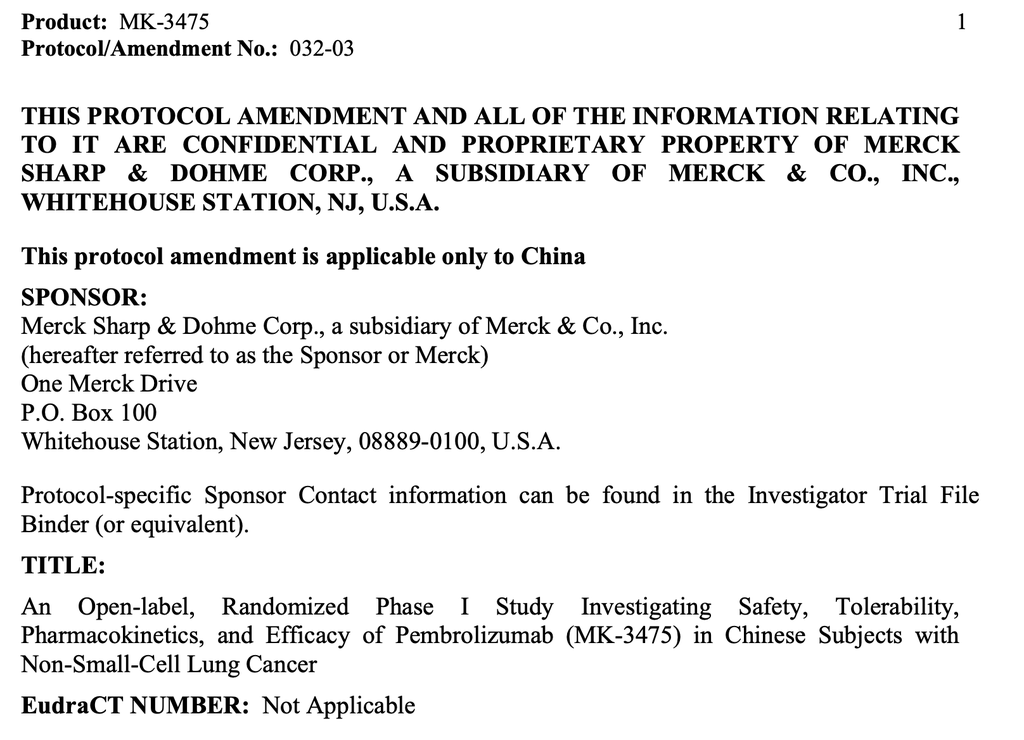

# Make sure you have a data specification document

If you don’t have one, make it.

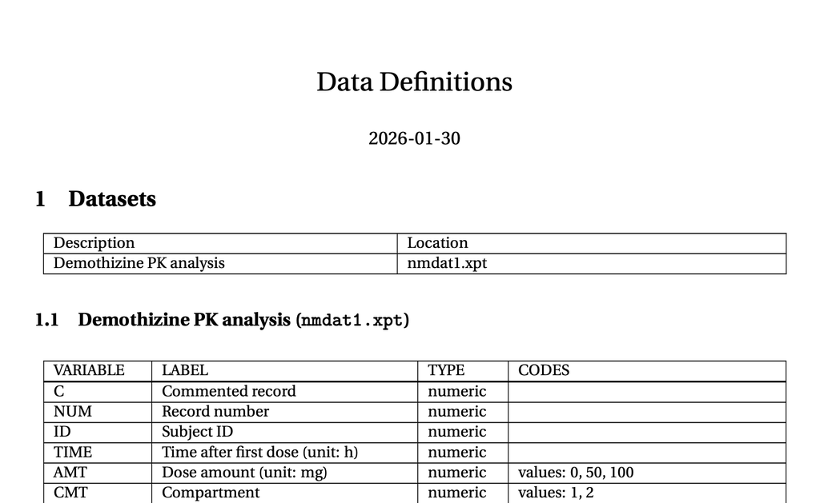

# Data inventory (PK)

- How much data do we have?
  - Subjects
  - Quantifiable observations
  - BLQ observations
- How does this inventory vary by
  - Dose regimens
  - Covariate levels

# Who is in our data set?

- Categorical covariates
  - Levels (e.g. Sex: Male, Female)
  - Count / percent
- Continuous covariates
  - Usually at baseline
  - Median / mean
  - SD
  - Range
- Continuous covariates by categorical

# Concentration time profiles

- Concentration versus time
- Concentration versus time after dose
- Plots stratified by meaningful covariates

**Ask**

1. Are we seeing concentrations in the expected range?
2. Are we seeing concentrations collected in the expected time range?
3. What models might this data support?
4. Are these models adquate to answer our questions?

# Visualization

https://graphicsprinciples.github.io/

[Cheat sheet](https://github.com/GraphicsPrinciples/CheatSheet/blob/master/NVSCheatSheet.pdf)